fossil

# miRNA enrichment bias, dug back up.

A test that called random miRNA lists enriched, and a fix that called almost nothing enriched. We regenerated the paper’s miRanda predictions and rebuilt its empirical test. 99.87% of the paper’s published target lists come back, Figure 1 lands on the published bars, and after correction 6 of 22 human and 0 of 7 mouse lists have an enriched term (paper: 5 and 0).

See the tables

## Fig. 1

Expected (hypergeometric, blue) and empirical (red) number of predicted targets in ‘ion transport’ (GO:0006811) for 39 random miRNAs, per 5-gene bin.

AgreesSame setup, regenerated predictions

Published

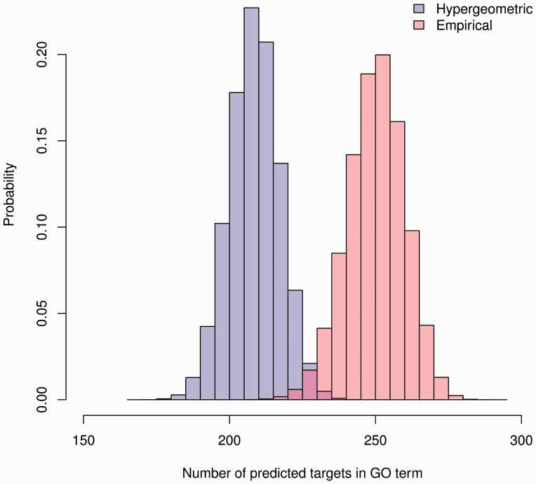

Our run

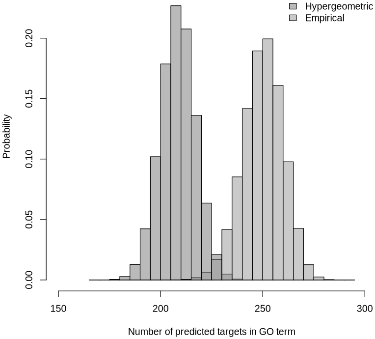

**Pixel size**

764 × 690

**Mean |Δ| grey**

4.52

**Pixels within ±24**

97.85%

**Ink distance (chamfer)**

0.13 px

**Best global shift**

0, 0 px

## Tables 1 and 2

Table 1: hypergeometric P of the mean of the empirical distribution, for the ten most biased terms. Table 2: GO terms significant after Benjamini–Hochberg correction (FDR < 0.05), published / ours.

Partly agreesBasic 28 of 29, multi-hit 28 of 29 calls

Table 1 (paper; recomputed from the paper’s S1 means; ours from our null; our rank)

| GO term | Paper | From S1 | Ours | Our rank |
| --- | --- | --- | --- | --- |
| GO:0006351 transcription, DNA-templated | 1.21e-28 | 1.21e-28 | **1.21e-28** | 1 |
| GO:0006355 regulation of transcription, DNA-dependent | 6.99e-25 | 6.99e-25 | **1.21e-24** | 2 |
| GO:0007165 signal transduction | 4.63e-18 | 4.63e-18 | **8.00e-18** | 3 |
| GO:0006468 protein phosphorylation | 4.34e-17 | 4.34e-17 | **4.34e-17** | 4 |
| GO:0055085 transmembrane transport | 1.39e-13 | 1.39e-13 | **1.39e-13** | 5 |
| GO:0015031 protein transport | 1.95e-13 | 1.95e-13 | **1.95e-13** | 6 |
| GO:0045944 positive regulation of transcription from RNA polymerase II promoter | 3.44e-12 | 3.44e-12 | **3.44e-12** | 7 |
| GO:0045893 positive regulation of transcription, DNA-dependent | 4.80e-12 | 4.80e-12 | **9.35e-12** | 9 |
| GO:0048011 neurotrophin TRK receptor signaling pathway | 7.67e-12 | 7.67e-12 | **7.67e-12** | 8 |
| GO:0007264 small GTPase mediated signal transduction | 1.22e-11 | 1.22e-11 | **1.22e-11** | 10 |

All 9,462 P-values of Supplementary Table S1 come back to 1e-9 when the mean is truncated, not rounded as the caption says (3,716 with rounding). Our own null puts the paper’s ten terms at ranks 1 to 10; 7 of the ten P-values are identical because the truncated means agree.

Table 2. Significant GO terms (published / ours)

| Study | Species | miRNAs | Basic | Multi-hit |
| --- | --- | --- | --- | --- |
| Arndt et al. (2009) | Human | 1 | 0 / **0** | 0 / **0** |
| Chartoumpekis et al. (2012) | Mouse | 10 | 0 / **0** | 17 / **17** |
| Chen et al. (2010) | Human | 176 | 6,017 / **6,010** ≠ | 1,193 / **1,300** ≠ |
| Chen et al. (2013b) | Human | 15 | 0 / **0** | 6 / **5** ≠ |
| Cheng et al. (2009) | Mouse | 1 | 0 / **0** | 0 / **0** |
| Collino et al. (2010) | Human | 11 | 0 / **1** ≠ | 0 / **0** |
| Davidson et al. (2010) | Human | 1 | 0 / **0** | 0 / **0** |
| Flavin et al. (2009) | Human | 2 | 0 / **0** | 0 / **0** |
| He et al. (2013) | Mouse | 8 | 0 / **0** | 0 / **0** |
| Hunter et al. (2008) | Human | 1 | 0 / **0** | 0 / **0** |
| Jiang et al. (2008) | Human | 18 | 0 / **0** | 0 / **0** |
| Keck-Wherley et al. (2011) | Mouse | 12 | 0 / **0** | 0 / **0** |
| Kraemer et al. (2013) | Human | 9 | 0 / **0** | 0 / **0** |
| Liang et al. (2013) | Mouse | 37 | 0 / **0** | 0 / **0** |
| Liu et al. (2010) | Mouse | 27 | 0 / **0** | 1 / **0** ≠ |
| Mizuguchi et al. (2011) | Human | 3 | 0 / **0** | 0 / **0** |
| Munch et al. (2013) | Human | 10 | 0 / **0** | 22 / **72** ≠ |
| Presneau and Eskandarpour (2013) | Human | 5 | 0 / **0** | 0 / **0** |
| Raponi et al. (2009) | Human | 15 | 0 / **0** | 239 / **120** ≠ |
| Romero-Cordoba et al. (2012) | Human | 130 | 5,573 / **5,550** ≠ | 206 / **266** ≠ |
| Sanchez-Diaz et al. (2013) | Human | 26 | 2,502 / **2,499** ≠ | 28 / **31** ≠ |
| Schonrock et al. (2010) | Mouse | 1 | 0 / **0** | 0 / **0** |
| Soh et al. (2013) | Human | 1 | 0 / **0** | 0 / **0** |
| Sokolov et al. (2012) | Human | 39 | 0 / **0** | 337 / **842** ≠ |
| Tanic and Andrés (2013) | Human | 46 | 3,353 / **3,360** ≠ | 317 / **526** ≠ |
| Wu et al. (2011) | Human | 25 | 2,480 / **2,473** ≠ | 138 / **192** ≠ |
| Yan et al. (2012) | Human | 1 | 0 / **0** | 0 / **0** |
| Zhang et al. (2013) | Human | 1 | 0 / **0** | 0 / **0** |
| Ziats and Rennert (2013) | Human | 25 | 0 / **0** | 0 / **0** |

Basic algorithm: the five large lists come back within 0.4% of the paper’s counts, and 28 of 29 lists get the same zero or non-zero call. Lists with any significant term: 6 of 22 human (paper 5) and 0 of 7 mouse (paper 0). The multi-hit algorithm agrees on 28 of 29 calls; its counts are not reproducible from the Methods (see the next section).

## Supplementary Tables S3 and S5

S3: the miRanda target genes of each published list (genes with a biological-process term). S5: the positive control, eight miRNAs tested together.

Agrees99.87% of S3’s targets; no extra gene

Target genes per list (S3 / ours; genes only in S3; only in ours)

| Study | Species | miRNAs | S3 | Ours | Only S3 | Only ours |
| --- | --- | --- | --- | --- | --- | --- |
| Arndt | Human | 1 | 1,400 | **1,397** | 3 | 0 |
| Chartoumpekis | Mouse | 10 | 4,158 | **4,157** | 1 | 0 |
| Chen | Human | 176 | 12,855 | **12,848** | 7 | 0 |
| Chen2 | Human | 15 | 6,079 | **6,066** | 13 | 0 |
| Cheng | Mouse | 1 | 729 | **729** | 0 | 0 |
| Collino | Human | 11 | 5,193 | **5,180** | 13 | 0 |
| Davidson | Human | 1 | 744 | **741** | 3 | 0 |
| Flavin | Human | 2 | 1,929 | **1,926** | 3 | 0 |
| He | Mouse | 8 | 5,521 | **5,517** | 4 | 0 |
| Hunter | Human | 1 | 447 | **445** | 2 | 0 |
| Jiang | Human | 18 | 7,306 | **7,293** | 13 | 0 |
| Keck-Wherley | Mouse | 12 | 6,872 | **6,872** | 0 | 0 |
| Kraemer | Human | 9 | 4,789 | **4,782** | 7 | 0 |
| Liang | Mouse | 37 | 10,524 | **10,521** | 3 | 0 |
| Liu | Mouse | 27 | 8,712 | **8,708** | 4 | 0 |
| Mizuguchi | Human | 3 | 2,496 | **2,490** | 6 | 0 |
| Munch | Human | 10 | 5,065 | **5,056** | 9 | 0 |
| Presneau | Human | 5 | 3,481 | **3,470** | 11 | 0 |
| Raponi | Human | 15 | 6,951 | **6,942** | 9 | 0 |
| Romero-Cordoba | Human | 130 | 12,416 | **12,404** | 12 | 0 |
| Sanchez-Diaz | Human | 26 | 7,811 | **7,793** | 18 | 0 |
| Schonrock | Mouse | 1 | 1,525 | **1,525** | 0 | 0 |
| Soh | Human | 1 | 832 | **829** | 3 | 0 |
| Sokolov | Human | 39 | 10,057 | **10,043** | 14 | 0 |
| Tanic | Human | 46 | 9,351 | **9,340** | 11 | 0 |
| Wu | Human | 25 | 7,820 | **7,809** | 11 | 0 |
| Yan | Human | 1 | 961 | **957** | 4 | 0 |
| Zhang | Human | 1 | 793 | **791** | 2 | 0 |
| Ziats | Human | 25 | 8,978 | **8,964** | 14 | 0 |

3 lists come back gene for gene (Cheng, Keck-Wherley, Schonrock). Over all 29, 155,595 of S3’s 155,795 study–gene pairs are ours and 0 of ours are not in S3. S5: our eight miRNAs target 1,049 genes (S5: 1,064); 1,552 terms are significant against S5’s 1,580, 1,551 in both, and ‘regulation of axonogenesis’ is among them.

## The multi-hit test

Table 2’s second column. Significant GO terms (BH FDR < 0.05) under readings of the method that each change one thing against ours.

DiffersCounts not reproducible from the Methods

**What it is.** The basic test counts each target gene once: a gene hit by one site of one miRNA weighs as much as a gene hit by ten miRNAs. The multi-hit test (Section 3.4) scores each gene by its predicted binding sites summed over the list’s miRNAs, and a term by the summed scores of its genes over the total. Both compare the list with 999,999 random lists, so both correct the targeting bias; the multi-hit version puts back convergence, several miRNAs hitting the same genes, to show the corrected test can still find biology.

**How much rests on it.** Little. The main claim (5 of 22 human and 0 of 7 mouse lists enriched after correction), Figure 1 and Table 1 stand on the basic test. From the multi-hit test the paper takes only a pattern, which our run shows too: lists enriched under the basic test stay enriched with fewer terms, and five of the paper’s six lists that gain terms gain them here (Liu does not).

Significant multi-hit terms per list: paper, then our readings; our reference at FDR 0.025–0.1; the FDR at which our ranking gives the paper’s count

| List | miRNAs | Paper | Reference | Other seed | Longest UTR | Sum, UTRs | Sum, transcripts | GO-gene denominator | All pairs | FDR 0.025–0.1 | FDR at paper’s count |
| --- | --- | --- | --- | --- | --- | --- | --- | --- | --- | --- | --- |
| Chen | 176 | 1,193 | **1,300** | 1,304 | 1,290 | 1,347 | 1,420 | 1,170 | 1,824 | 1,013–1,676 | 0.0392 |
| Romero-Cordoba | 130 | 206 | **266** | 267 | 289 | 230 | 255 | 217 | 372 | 141–502 | 0.0386 |
| Tanic | 46 | 317 | **526** | 524 | 528 | 489 | 523 | 448 | 636 | 320–746 | 0.0236 |
| Sokolov | 39 | 337 | **842** | 840 | 818 | 650 | 541 | 930 | 1,640 | 639–1,121 | 0.00275 |
| Sanchez-Diaz | 26 | 28 | **31** | 32 | 32 | 24 | 27 | 13 | 28 | 5–126 | 0.0486 |
| Wu | 25 | 138 | **192** | 193 | 182 | 156 | 170 | 152 | 208 | 102–379 | 0.0368 |
| Chen2 | 15 | 6 | **5** | 5 | 5 | 5 | 1 | 5 | 4 | 5–11 | 0.0568 |
| Raponi | 15 | 239 | **120** | 116 | 120 | 148 | 160 | 118 | 244 | 71–206 | 0.117 |
| Collino | 11 | 0 | **0** | 0 | 0 | 0 | 0 | 0 | 7 | 0–1 |  |
| Munch | 10 | 22 | **72** | 72 | 74 | 47 | 45 | 63 | 65 | 48–141 | 0.00757 |
| Presneau | 5 | 0 | **0** | 0 | 0 | 0 | 0 | 0 | 26 | 0–12 |  |
| Liu (mouse) | 27 | 1 | **0** | 0 | 0 | 0 | 0 | 0 | 0 | 0–0 | 0.232 |
| Chartoumpekis (mouse) | 10 | 17 | **17** | 3 | 17 | 2 | 2 | 17 | 0 | 2–68 | 0.0495 |

**Why the counts differ.** The paper does not say how sites are counted on a gene with several transcripts, or whether sites on pairs failing the score and energy cut count, and no supplementary table records site counts. The targets feeding both columns agree with S3 to 99.8%, so the gap lies in the site counts. No reading reproduces the paper, and the errors point both ways: seven lists come out too high, three too low. The paper’s counts are not ours at another threshold either: the FDR that would give them runs from 0.0027 to 0.23. Many multi-hit P-values sit near the cut, so the counts are fragile; under another seed Chartoumpekis goes from 17 to 3, so its exact match is chance.

**Comparing counts.** `table2.csv` gives ours − paper and (ours − paper) / paper. The paper publishes no multi-hit term lists, so the term sets cannot be compared; the readings, the FDR range and the FDR at the paper’s count show how far a count can move.

## What came back

**The GO universe**

Ensembl 75’s BioMart tables survive as MySQL dumps. By gene name, direct annotations, all evidence codes, they give the paper’s 15,733 human genes and all 9,462 of S1’s term sizes.

**The miRanda thresholds**

“Score > 155, energy < −20” is applied to miRanda’s per-UTR totals, inclusive (score ≥ 155, energy ≤ −20), on a run with miRanda’s defaults. Per-site filtering finds a third of S3’s genes; a strict > 155 misses about 3%.

**The 3′ UTRs**

Cut from the Ensembl 75 GTF and genome; they equal BioMart’s 3′ UTRs for all 104,763 coding transcripts. Haplotype and patch sequences need their shared regions copied from the parent chromosome.

**The empirical P-value**

S5’s P-values are counts over 999,999 draws with no pseudo-count, the overlap divides by all target genes (S5’s 1,064 include genes without a GO term), and BH runs over all 9,462 terms.

**S5’s eight miRNAs**

Not the eight with the most targets in the term, as the text says: S5 rules out every miRNA that hits a term it reports as empty, and exactly eight survive.

**A spreadsheet in the way**

S3 lists MARCH1, MARCH5, SEPT7 and SEP15 as dates (36951.0 is 1 March 2001).

## What stayed buried

- The authors’ Python script (sgjlab.org/empirical-go no longer resolves)
- Table 3 (rice): psRNATarget’s 2011 server and the agriGO tables it used
- The robustness runs of Section 3.3: PITA v6, DIANA-microT-v4, starBase v2 CLIP sets and DAVID’s 2014 BP_FAT
- The multi-hit counts of Table 2: how sites are counted per gene is not stated, and six readings do not reproduce them
- Why 200 of S3’s 155,795 study–gene pairs are not in ours: the genes have short 3′ UTRs here, and no Ensembl 75 table we found gives them longer ones

The bias the paper reports comes back: with regenerated predictions, the mean ion-transport count of 39 random miRNAs is 250.6, and the hypergeometric test calls it significant at 5.97e-07. Corrected, almost nothing is enriched.

## What we matched

Figure 1 is a base R plot: two histograms of probability per 5-gene bin. We draw it with base R on the published pixel grid. The plot region comes from the tick marks of the published axes, so a bar lands where the paper’s would. Only the raster resolution, the y-title and legend positions and the fill colours are fitted, on a render of the bar heights read off the published figure.

**Our run**

miRanda 3.3a (bioconda build) on all 2,578 human and 1,908 mouse miRBase 20 mature miRNAs against every Ensembl 75 3′ UTR; the empirical null rebuilt from the Methods and checked against S1, S3 and S5.

**Axes**

One linear map per axis from the tick marks (x = 150 to 300, y = 0 to 0.20), R’s 4% axis extension, and half a pixel for the pixel centre.

## The session

Session not recorded: no log of the agent session was kept for this reproduction.